# Wyjaśnialne Uczenie Maszynowe - Praca domowa 6

Poniżej zestawienie wykresów Partial Dependence Profiles and Accumulated Local Dependence dla modelu lasu losowego. Możemy zauważyć, że wykresy te są do siebie bardzo podobne. Zauważalne jest jedynie przesunięcie wykresów ALE względem osi y. Może to świadczyć o addtywności modelu.

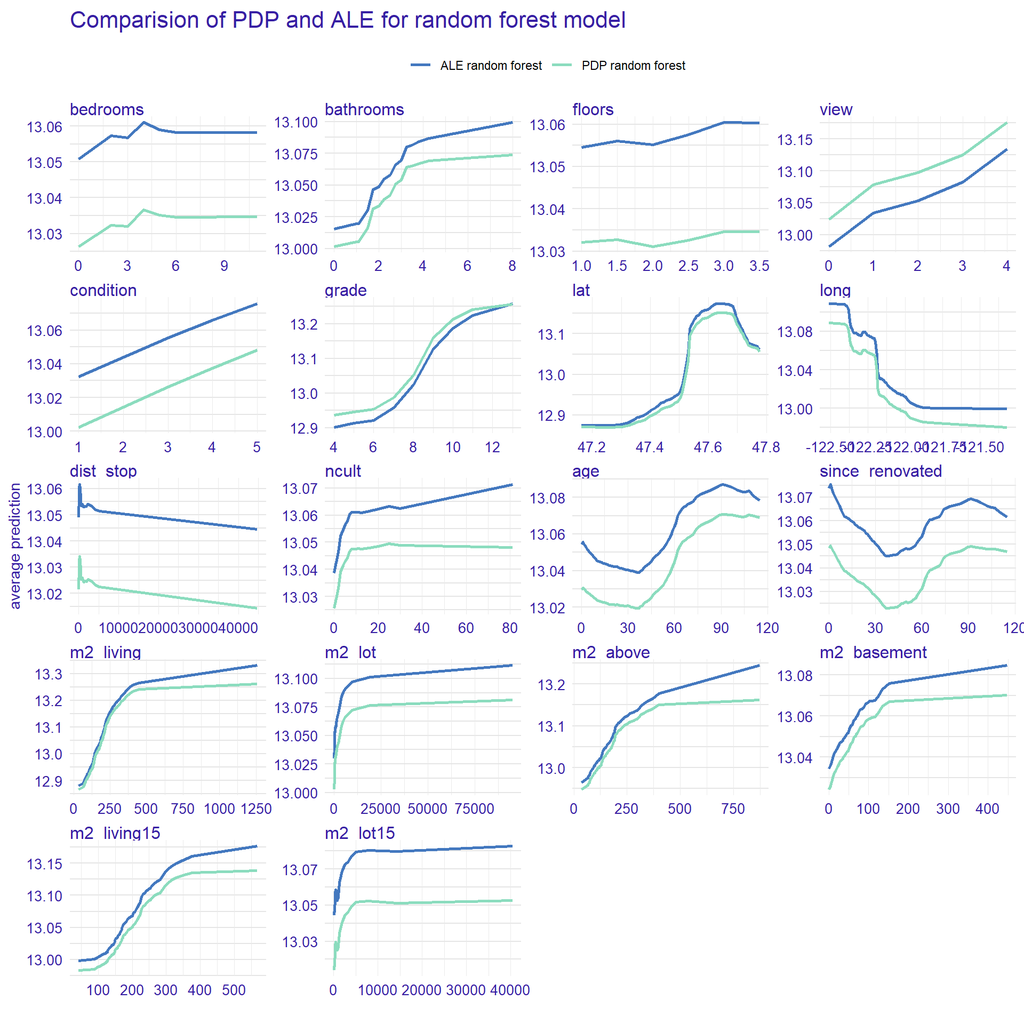

```r
pdp_rf$`_label_` <- "PDP random forest"
ald_rf$`_label_` <- "ALE random forest"
plot(pdp_rf, ald_rf, variables = variables_model) + facet_wrap(~`_vname_`, scales = "free", ncol = 4) + ggtitle("Comparision of PDP and ALE for random forest model") + labs(subtitle = "")
```

W celu porównania modeli, poniżej zestawienie wykresów PDP dla modeli takich jak:

- drzewo decyzyjne
- gbm
- las losowy
- xgboost.

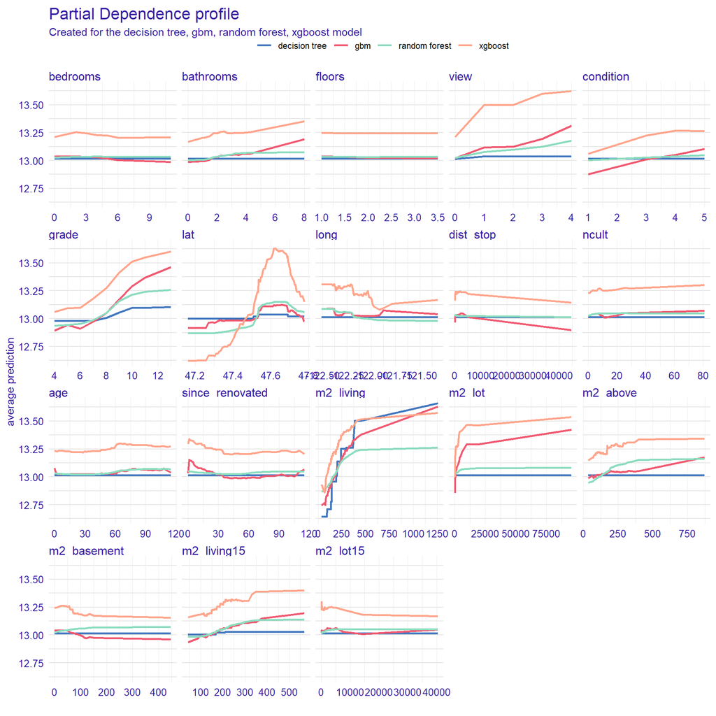

```r
load("../../../../../Documents/GitHub/InterpretableHouseSalePrices/Explanations/pdp_ald/pdp_decisiontree.rda")
load("../../../../../Documents/GitHub/InterpretableHouseSalePrices/Explanations/pdp_ald/pdp_gbm.rda")
load("../../../../../Documents/GitHub/InterpretableHouseSalePrices/Explanations/pdp_ald/pdp_xgb.rda")
pdp_rf$`_label_` <- "random forest"

plot(pdp_decisiontree, pdp_gbm, pdp_rf, pdp_xgb, variables = variables_model) #+ facet_wrap(~`_vname_`, scales = "free", ncol = 4)
```

```r
variables_model <- c("bedrooms", "bathrooms", "m2_living", "m2_lot", "floors", "view",
                     "condition", "grade", "m2_above", "m2_basement", "zipcode",
                     "lat", "long", "m2_living15", "m2_lot15", "dist_stop",
                     "ncult", "age", "since_renovated")
```

### Podsumowanie

Profile PDP pomagają w łatwy sposób podsumować wpływ danej zmiennej na predykcję modelu. Są łatwe i intuicyjne. Możemy porównywać je dla różnych modeli, co pozwala na określenie, na co kolejne modele zwracają uwagę. Dodatowo zastowanie profili ALE pozwana na określenie czy w modelu występują interakcje oraz czy dane są istotnie skorelowane.

Kody do wyliczenia [PDP oraz ALE](https://github.com/kozaka93/InterpretableHouseSalePrices/tree/master/Explanations/pdp_ald) oraz [budowy przedstawionych modeli](https://github.com/kozaka93/InterpretableHouseSalePrices/tree/master/Models/PredictiveModels) zostały umieszczone na repozytorium.